# How I Found My Next Student Rental Property

Dylan McKeighan

December 15th, 2021

# A little introduction to my project

The idea for this project came from a conversation I had just a few months back. I was catching-up with an old roommate of mine who has since found himself exploring the world of real estate. He was explaining to me how his research has led him to focus his attention on student rental properties, just like the one we used to live in together. As a poor college student myself, the idea of generating some passive income is more than enticing. It was very soon in the conversation, however, that I realized his method of finding properties to rent was fairly inefficient. The thought then came to me: if my friend can have so much success with his current strategy to find properties, surely I could have the same success by developing an even better strategy! Thus, I set-out to find my next student rental property and here’s what I found…

# Planning

First, I wanted to narrow down the search of properties to those which are located near university campuses that will **consistently have the greatest amount of students looking for a place to live.**  
To do this, I searched the web for the universities with the greatest undergraduate population. I scraped (using rvest) this [wikipedia page](https://en.wikipedia.org/wiki/List_of_United_States_public_university_campuses_by_enrollment) that had a neatly kept list of the Top 10 Most Populous Universities and their undergraduate populations from 2009 to present.

Here’s a look at the first 10 rows:

| year_start | year_finish | campus | city | state | pop |
| --- | --- | --- | --- | --- | --- |
| 2020 | 2021 | Texas A&M University | College Station | Texas | 73284 |
| 2020 | 2021 | University of Central Florida | Orlando | Florida | 70406 |
| 2020 | 2021 | Ohio State University | Columbus | Ohio | 67772 |
| 2020 | 2021 | University of Florida | Gainesville | Florida | 60613 |
| 2020 | 2021 | Florida International University | Miami | Florida | 56627 |
| 2020 | 2021 | University of Illinois at Urbana–Champaign | Urbana/Champaign | Illinois | 56299 |
| 2020 | 2021 | Arizona State University | Tempe | Arizona | 54000 |
| 2020 | 2021 | Georgia State University | Atlanta | Georgia | 52530 |
| 2020 | 2021 | University of Minnesota | Minneapolis/Saint Paul | Minnesota | 52376 |
| 2020 | 2021 | University of Texas at Austin | Austin | Texas | 51992 |

And here’s a look at each campus on the Wikipedia page through the years:  
*Note that some campuses made the list only a few times, whereas others were on the list every year.*

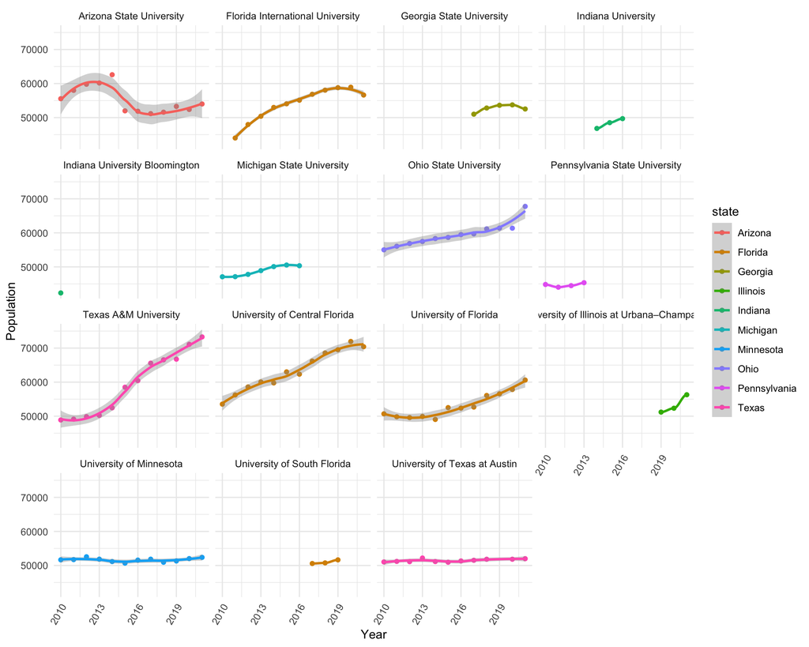

Finally, here is a list of the schools that were in the Top 10 Most Populous Universities for over ten years and the number of years they were on it. These schools **consistently had the greatest amount of students looking for a place to live.**

| campus | num |
| --- | --- |
| Arizona State University | 12 |
| Ohio State University | 12 |
| Texas A&M University | 12 |
| University of Central Florida | 12 |
| University of Florida | 12 |
| University of Minnesota | 12 |
| Florida International University | 11 |
| University of Texas at Austin | 11 |

# But, wait…

What if these universities house the majority of their students on campus? To account for this, I had to do a little more digging. I visited a variety of sources to determine what percent of students typically live on-campus vs off-campus at each of the previously mentioned universities, and then compiled a list. Here’s a look at those percentages:

| campus | on | off |
| --- | --- | --- |
| Texas A&M University | 20 | 80 |
| University of Central Florida | 15 | 85 |
| Ohio State University | 24 | 76 |
| University of Florida | 16 | 84 |
| Florida International University | 5 | 95 |
| University of Illinois at Urbana–Champaign | 50 | 50 |
| Arizona State University | 19 | 81 |
| Georgia State University | 15 | 85 |
| University of Minnesota | 13 | 87 |
| University of Texas at Austin | 8 | 92 |
| University of South Florida | 10 | 90 |
| Michigan State University | 6 | 94 |
| Indiana University | 27 | 73 |
| Pennsylvania State University | 26 | 74 |
| Indiana University Bloomington | 27 | 73 |

I then used these percentages to estimate the amount of the undergraduate students that will be looking for off-campus housing at each of these universities:  
*Note: although Texas A&M has a higher student population overall, the University of Central Florida most likely has more students in search of off-campus housing (and, hopefully, my rental property!)*

| year_start | year_finish | campus | city | state | pop | off_camp | pop_adjusted |
| --- | --- | --- | --- | --- | --- | --- | --- |
| 2020 | 2021 | University of Central Florida | Orlando | Florida | 70406 | 0.85 | 59845.10 |
| 2020 | 2021 | Texas A&M University | College Station | Texas | 73284 | 0.80 | 58627.20 |
| 2020 | 2021 | Florida International University | Miami | Florida | 56627 | 0.95 | 53795.65 |
| 2020 | 2021 | Ohio State University | Columbus | Ohio | 67772 | 0.76 | 51506.72 |
| 2020 | 2021 | University of Florida | Gainesville | Florida | 60613 | 0.84 | 50914.92 |
| 2020 | 2021 | University of Texas at Austin | Austin | Texas | 51992 | 0.92 | 47832.64 |
| 2020 | 2021 | University of Minnesota | Minneapolis/Saint Paul | Minnesota | 52376 | 0.87 | 45567.12 |
| 2020 | 2021 | Georgia State University | Atlanta | Georgia | 52530 | 0.85 | 44650.50 |
| 2020 | 2021 | Arizona State University | Tempe | Arizona | 54000 | 0.81 | 43740.00 |
| 2020 | 2021 | University of Illinois at Urbana–Champaign | Urbana/Champaign | Illinois | 56299 | 0.50 | 28149.50 |
| 2019 | 2020 | University of Central Florida | Orlando | Florida | 71948 | 0.85 | 61155.80 |
| 2019 | 2020 | Texas A&M University | College Station | Texas | 71109 | 0.80 | 56887.20 |
| 2019 | 2020 | Florida International University | Miami | Florida | 58928 | 0.95 | 55981.60 |
| 2019 | 2020 | University of Florida | Gainesville | Florida | 57841 | 0.84 | 48586.44 |
| 2019 | 2020 | University of Texas at Austin | Austin | Texas | 51832 | 0.92 | 47685.44 |

Here is a look at the mean of the adjusted populations for each university since 2009. The schools which are consistently in the Top Ten Most Populous Universities in the country are highlighted in yellow.

| campus | mean_pop |
| --- | --- |
| University of Central Florida | 53843.68 |
| Florida International University | 51281.26 |
| Texas A&M University | 47518.87 |
| University of Texas at Austin | 47349.22 |
| Michigan State University | 45913.49 |
| University of South Florida | 45893.40 |
| Ohio State University | 45174.15 |
| University of Minnesota | 44928.68 |
| Georgia State University | 44829.00 |
| Arizona State University | 44711.19 |
| University of Florida | 44640.12 |
| Indiana University | 35289.66 |
| Pennsylvania State University | 33059.87 |
| Indiana University Bloomington | 30913.31 |
| University of Illinois at Urbana–Champaign | 26637.67 |

If I am going to find a rental property, these seem like a pretty good place to start looking! These universities **consistently have the greatest amount of students looking for a place to live off-campus.**

# Finding the Property

Finding the ideal property was no easy task. Although the web seems to be filled with an enormous amount of real estate data, most of this data is either kept private or is untrustworthy. In order to get my hands on the data I needed, I had to write some code that could scrape one of the most popular real estate websites: [realtor.com](https://www.realtor.com/).  
*Note: I made sure to check www.realtor.com/robots.txt to ensure that I wasn’t scraping pages that are forbiden*  
Here’s a look at the for-loop I created to find the metrics I was looking for:

```r
library(tidyverse)
library(rvest)

cities <- c("College-Station_TX", "Orlando_FL", "Miami_FL", "Columbus_OH",
            "Gainesville_FL", "Austin_TX", "Minneapolis_MN", "Atlanta_GA",
            "Tempe_AZ", "Champaign_IL", "Tampa_FL", "East-Lansing_MI",
            "University-Park_IL", "Bloomington_IN")

df1 = data.frame()

for (city in cities) {
  city_page = paste0("https://www.realtor.com/realestateandhomes-search/", city, "/beds-1/sqft-500/pg-")

  for (page_result in 1:8) {

    link = paste0(city_page, page_result, "")
    Sys.sleep(time = 10)
    page = read_html(link)

    address = page %>% html_nodes(".srp-address-redesign") %>% html_text()
    price = page %>% html_nodes(".srp-page-price > .bowEcH") %>% html_text()
    beds = page %>% html_nodes(".srp_list:nth-child(1)") %>% html_text()
    baths = page %>% html_nodes(".srp_list:nth-child(2)") %>% html_text()
    sq_ft = page %>% html_nodes(".srp_list:nth-child(3)") %>% html_text()
    location = rep(city, length(address))

    df1 = rbind(df1, data.frame(address, price, beds, baths, sq_ft, location,
                                stringsAsFactors = FALSE))

    print(paste("Page:", page_result))

    Sys.sleep(time = 5)
  }

  Sys.sleep(time=20)


}

write_csv(df1, file = "./../data/realtor.csv")
```

| address | price | beds | baths | sq_ft | city |
| --- | --- | --- | --- | --- | --- |
| 1 E Main St Ste 409, Champaign, IL 61820 | 210000 | 2 | 1.5 | 1185 | Champaign |
| 1 W Lake St Apt 309, Minneapolis, MN 55408 | 135000 | 1 | 1.0 | 735 | Minneapolis |
| 100 3rd Ave S Unit 605, Minneapolis, MN 55401 | 565000 | 2 | 2.0 | 1546 | Minneapolis |
| 100 S Eola Dr Unit 1113, Orlando, FL 32801 | 635000 | 2 | 2.5 | 1885 | Orlando |
| 100 S Eola Dr Unit 1211, Orlando, FL 32801 | 575000 | 2 | 2.5 | 2100 | Orlando |
| 1000 Brickell Plz Ph 6007, Miami, FL 33131 | 2715000 | 3 | 3.5 | 1912 | Miami |
| 1000 Brickell Plz Unit 3502, Miami, FL 33131 | 2050000 | 3 | 3.5 | 1909 | Miami |
| 1000 Spring Loop Apt 1306, College Station, TX 77840 | 174500 | 2 | 2.5 | 1168 | College_Station |
| 1000 W Horatio St Apt 207, Tampa, FL 33606 | 239999 | 1 | 1.0 | 631 | Tampa |
| 10000 SW 52nd Ave Unit V137, Gainesville, FL 32608 | 169900 | 1 | 1.0 | 965 | Gainesville |